# Table of Contents

**Kernel Author:**  
[Bhishan Poudel, Data Scientist, Ph.D Astrophysics](https://bhishanpdl.github.io/) .

# Data Description

> The datasets contains transactions made by credit cards in September 2013 by european cardholders.

> This dataset presents transactions that occurred in two days, where we have 492 frauds out of 284,807 transactions.

> The dataset is highly unbalanced, the positive class (frauds) account for 0.172% of all transactions.

> It contains only numerical input variables which are the result of a PCA transformation.

> Unfortunately, due to confidentiality issues, we cannot provide the original features and more background information about the data.

> Features V1, V2, ... V28 are the principal components obtained with PCA, the only features which have not been transformed with PCA are 'Time' and 'Amount'.

> Feature 'Time' contains the seconds elapsed between each transaction and the first transaction in the dataset. The feature 'Amount' is the transaction Amount, this feature can be used for example-dependant cost-senstive learning.

> Feature 'Class' is the response variable and it takes value 1 in case of fraud and 0 otherwise.m

# Business Problem

# Introduction to Pycaret

[Pycaret](https://github.com/pycaret/pycaret) is a high level python module which requires very few lines of code to solve the machine learning problem at hand. This module is useful when dealing with projects with extreme less time constraints.

It has classes like

```
anomaly, classification, clustering, datasets,
nlp, preprecess and regression
```

.

Some resources for pycaret:

- [pycaret github](https://github.com/pycaret/pycaret)
- [pycaret classification 101](https://github.com/pycaret/pycaret/blob/master/Tutorials/Binary%20Classification%20Tutorial%20Level%20Beginner%20-%20%20CLF101.ipynb)
- [pycaret classification 102](https://github.com/pycaret/pycaret/blob/master/Tutorials/Binary%20Classification%20Tutorial%20Level%20Intermediate%20-%20CLF102.ipynb)
- [Running Low on Time? Use PyCaret to Build your Machine Learning Model in Seconds](https://www.analyticsvidhya.com/blog/2020/05/pycaret-machine-learning-model-seconds/)

# Imports

```python
import time

time_start_notebook = time.time()
```

```python
import numpy as np
import pandas as pd
import seaborn as sns
import os
from pathlib import Path

from tqdm import tqdm_notebook as tqdm
import matplotlib.pyplot as plt

%matplotlib inline
%config InlineBackend.figure_format = 'retina'
plt.style.use('ggplot')

# random state
SEED=100

home = os.path.expanduser('~')

[(x.__name__,x.__version__) for x in [np,pd,sns]]
```

[('numpy', '1.18.4'), ('pandas', '1.0.3'), ('seaborn', '0.10.1')]

```python
from zipfile import ZipFile
```

```python
import sys
ENV_COLAB = 'google.colab' in sys.modules

if ENV_COLAB:
    !pip install ipywidgets
    !pip install pycaret
    !jupyter nbextension enable --py widgetsnbextension

    from pycaret.utils import enable_colab
    enable_colab()
    # set OMP_NUM_THREADS=1 for hpsklearn package
    #!export OMP_NUM_THREADS=1
    print('Environment: Google Colab')
```

```
Enabling notebook extension jupyter-js-widgets/extension...
      - Validating: OK
Colab mode activated.
Environment: Google Colab
```

```python
import pycaret
from pycaret.utils import version
import pycaret.classification as pyc

version()
```

```
1.0.0
```

# Useful Functions

```python
def compare_new_models(name,desc,mean_row,df_eval=None,sort='Accuracy',show=True):
    """Create dataframe from output of pycaret new model.
    Parameters
    -----------
    name: str
        Name of the model. eg. xgboost
    desc: str
        Description of the model. e.g tuned,calibrated
    mean_row: str
        The line copied from jupyter notebook output from
        pycaret new model. Note that fields are separated
        with tabs.
        e.g.
        Mean	0.9992	0.9663	0.7214	0.8299	0.7679	0.7675
    df_eval: Pandas Dataframe
        Template pandas dataframe
    sort: str
       One of following string: Accuracy, AUC, Recall, Precision
                                F1, Kappa


    Returns:
       Pandas Dataframe.


    """
    mean_row_lst = mean_row.split('\t')
    assert len(mean_row_lst) == 7

    if not isinstance(df_eval, pd.DataFrame):
        df_eval = pd.DataFrame({'Model': [],
                                'Description':[],
                                'Accuracy':[],
                                'AUC':[],
                                'Recall':[],
                                'Precision':[],
                                'F1':[],
                                'Kappa':[]
                               })

    acc,auc,rec,pre,f1,kap = mean_row.split('\t')[1:]
    row = [name,desc,acc,auc,rec,pre,f1,kap]

    df_eval.loc[len(df_eval)] = row
    df_eval = df_eval.drop_duplicates()\
                     .sort_values(sort,ascending=False)
    df_eval.index = range(len(df_eval))

    df_style = (df_eval.style.apply(lambda ser:
                ['background: lightblue'
                 if ser.name == sort else ''
                 for _ in ser]))

    if show:
        display(df_style)

    return df_eval
```

# Load the data

```python
ifile = 'https://github.com/bhishanpdl/Datasets/blob/master/fraud_detection/creditcard.csv.zip?raw=true'
df = pd.read_csv(ifile,compression='zip')
print(df.shape)
df.head()
```

```
(284807, 31)
```

|  | Time | V1 | V2 | V3 | V4 | V5 | V6 | V7 | V8 | V9 | V10 | V11 | V12 | V13 | V14 | V15 | V16 | V17 | V18 | V19 | V20 | V21 | V22 | V23 | V24 | V25 | V26 | V27 | V28 | … |
| --- | --- | --- | --- | --- | --- | --- | --- | --- | --- | --- | --- | --- | --- | --- | --- | --- | --- | --- | --- | --- | --- | --- | --- | --- | --- | --- | --- | --- | --- | --- |
| 0 | 0.0 | -1.359807 | -0.072781 | 2.536347 | 1.378155 | -0.338321 | 0.462388 | 0.239599 | 0.098698 | 0.363787 | 0.090794 | -0.551600 | -0.617801 | -0.991390 | -0.311169 | 1.468177 | -0.470401 | 0.207971 | 0.025791 | 0.403993 | 0.251412 | -0.018307 | 0.277838 | -0.110474 | 0.066928 | 0.128539 | -0.189115 | 0.133558 | -0.021053 | … |
| 1 | 0.0 | 1.191857 | 0.266151 | 0.166480 | 0.448154 | 0.060018 | -0.082361 | -0.078803 | 0.085102 | -0.255425 | -0.166974 | 1.612727 | 1.065235 | 0.489095 | -0.143772 | 0.635558 | 0.463917 | -0.114805 | -0.183361 | -0.145783 | -0.069083 | -0.225775 | -0.638672 | 0.101288 | -0.339846 | 0.167170 | 0.125895 | -0.008983 | 0.014724 | … |
| 2 | 1.0 | -1.358354 | -1.340163 | 1.773209 | 0.379780 | -0.503198 | 1.800499 | 0.791461 | 0.247676 | -1.514654 | 0.207643 | 0.624501 | 0.066084 | 0.717293 | -0.165946 | 2.345865 | -2.890083 | 1.109969 | -0.121359 | -2.261857 | 0.524980 | 0.247998 | 0.771679 | 0.909412 | -0.689281 | -0.327642 | -0.139097 | -0.055353 | -0.059752 | … |
| 3 | 1.0 | -0.966272 | -0.185226 | 1.792993 | -0.863291 | -0.010309 | 1.247203 | 0.237609 | 0.377436 | -1.387024 | -0.054952 | -0.226487 | 0.178228 | 0.507757 | -0.287924 | -0.631418 | -1.059647 | -0.684093 | 1.965775 | -1.232622 | -0.208038 | -0.108300 | 0.005274 | -0.190321 | -1.175575 | 0.647376 | -0.221929 | 0.062723 | 0.061458 | … |
| 4 | 2.0 | -1.158233 | 0.877737 | 1.548718 | 0.403034 | -0.407193 | 0.095921 | 0.592941 | -0.270533 | 0.817739 | 0.753074 | -0.822843 | 0.538196 | 1.345852 | -1.119670 | 0.175121 | -0.451449 | -0.237033 | -0.038195 | 0.803487 | 0.408542 | -0.009431 | 0.798278 | -0.137458 | 0.141267 | -0.206010 | 0.502292 | 0.219422 | 0.215153 | … |

```python
#ifile = Path.home() / 'Datasets/kaggle/creditcard/creditcard.csv.zip'
#zip_file = ZipFile(ifile)
#df = pd.read_csv(zip_file.open('creditcard.csv'))
#print(df.shape)
#df.head()
```

```python
target = 'Class'
features = df.columns.drop(target)
df[target].value_counts(normalize=True)*100
```

```
0    99.827251
1     0.172749
Name: Class, dtype: float64
```

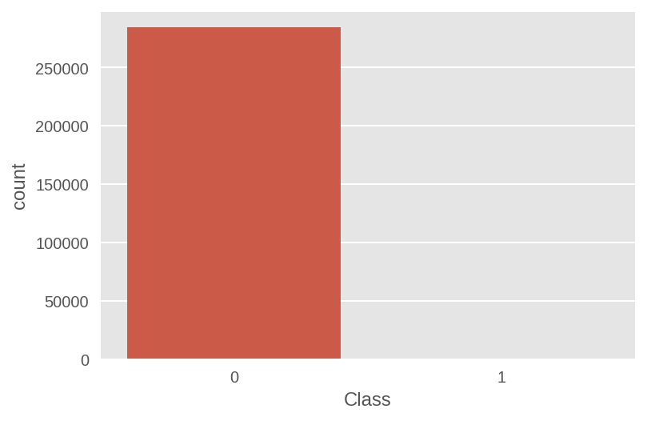

```python
sns.countplot(df[target])
```

# Train test split with stratify

```python
from sklearn.model_selection import train_test_split

df_train, df_test = train_test_split(
    df,test_size=0.2, random_state=SEED,
    stratify=df[target])

print(df_train.shape)
df_train.head()
```

```
(227845, 31)
```

|  | Time | V1 | V2 | V3 | V4 | V5 | V6 | V7 | V8 | V9 | V10 | V11 | V12 | V13 | V14 | V15 | V16 | V17 | V18 | V19 | V20 | V21 | V22 | V23 | V24 | V25 | V26 | V27 | V28 | … |
| --- | --- | --- | --- | --- | --- | --- | --- | --- | --- | --- | --- | --- | --- | --- | --- | --- | --- | --- | --- | --- | --- | --- | --- | --- | --- | --- | --- | --- | --- | --- |
| 211885 | 138616.0 | -1.137612 | 2.345154 | -1.767247 | 0.833982 | 0.973168 | -0.073571 | 0.802433 | 0.733137 | -1.154087 | -0.520340 | 0.494117 | 0.799935 | 0.494576 | -0.479666 | -0.917177 | -0.184117 | 1.189459 | 0.937244 | 0.960749 | 0.062820 | 0.114953 | 0.430613 | -0.240819 | 0.124011 | 0.187187 | -0.402251 | 0.196277 | 0.190732 | … |
| 12542 | 21953.0 | -1.028649 | 1.141569 | 2.492561 | -0.242233 | 0.452842 | -0.384273 | 1.256026 | -0.816401 | 1.964560 | -0.014216 | 0.432153 | -2.140921 | 2.274477 | 0.114128 | -1.652894 | -0.617302 | 0.243791 | -0.426168 | -0.493177 | 0.350032 | -0.380356 | -0.037432 | -0.503934 | 0.407129 | 0.604252 | 0.233015 | -0.433132 | -0.491892 | … |
| 270932 | 164333.0 | -1.121864 | -0.195099 | 1.282634 | -3.172847 | -0.761969 | -0.287013 | -0.586367 | 0.496182 | -2.352349 | 0.350551 | -1.319688 | -0.942001 | 1.082210 | -0.425735 | 0.036748 | 0.380392 | -0.033353 | 0.204609 | -0.801465 | -0.113632 | -0.328953 | -0.856937 | -0.056198 | 0.401905 | 0.406813 | -0.440140 | 0.152356 | 0.030128 | … |
| 30330 | 35874.0 | 1.094238 | -0.760568 | -0.392822 | -0.611720 | -0.722850 | -0.851978 | -0.185505 | -0.095131 | -1.122304 | 0.367009 | 1.378493 | -0.724216 | -1.105406 | -0.480170 | 0.220826 | 1.745743 | 0.740817 | -0.728827 | 1.016740 | 0.354148 | -0.227392 | -1.254285 | 0.022116 | -0.141531 | 0.114515 | -0.652427 | -0.037897 | 0.051254 | … |
| 272477 | 165107.0 | 2.278095 | -1.298924 | -1.884035 | -1.530435 | -0.649500 | -0.996024 | -0.466776 | -0.438025 | -1.612665 | 1.631133 | -1.126000 | -0.938760 | 0.300621 | -0.119667 | -0.585453 | -1.106244 | 0.690235 | -0.124401 | -0.075649 | -0.341708 | 0.123892 | 0.815909 | -0.072537 | 0.784217 | 0.403428 | 0.193747 | -0.043185 | -0.058719 | … |

# Pycaret Setup

- `setup` function will automatically infer datatypes, but if we see wrong data inference, we can use parameters `numeric_features` and `categorical_features`.

```
setup(data, target, train_size=0.7, sampling=True, sample_estimator=None, categorical_features=None, categorical_imputation='constant', ordinal_features=None, high_cardinality_features=None, high_cardinality_method='frequency', numeric_features=None, numeric_imputation='mean', date_features=None, ignore_features=None, normalize=False, normalize_method='zscore', transformation=False, transformation_method='yeo-johnson', handle_unknown_categorical=True, unknown_categorical_method='least_frequent', pca=False, pca_method='linear', pca_components=None, ignore_low_variance=False, combine_rare_levels=False, rare_level_threshold=0.1, bin_numeric_features=None, remove_outliers=False, outliers_threshold=0.05, remove_multicollinearity=False, multicollinearity_threshold=0.9, create_clusters=False, cluster_iter=20, polynomial_features=False, polynomial_degree=2, trigonometry_features=False, polynomial_threshold=0.1, group_features=None, group_names=None, feature_selection=False, feature_selection_threshold=0.8, feature_interaction=False, feature_ratio=False, interaction_threshold=0.01, session_id=None, silent=False, profile=False)

sampling: bool, default = True
When the sample size exceeds 25,000 samples, pycaret will build a base estimator at various sample sizes from the original dataset. This will return a performance  plot of AUC, Accuracy, Recall, Precision, Kappa and F1 values at various sample  levels, that will assist in deciding the preferred sample size for modeling.
The desired sample size must then be entered for training and validation in the  pycaret environment. When sample_size entered is less than 1, the remaining dataset  (1 - sample) is used for fitting the model only when finalize_model() is called.
```

```python
experiment_may31_2020 = pyc.setup(df_train,'Class',
                                  train_size=0.8,
                                  session_id=SEED,
                                  sampling= True,
                                  silent=True,
                                  profile=False
                                 )

# use silent = True to check inferred datatypes
# then assign numeric and categorical features yourself.
#
# if sampling = False, 100% of data is used and its too slow
# if sampling = True, we need to enter number eg. 0.3 ourself.

"""
Here, we have data > 25k rows, so I have chosen 0.3 or 30% of data
for validation purposes.

""";
```

```
Setup Succesfully Completed!
```

|  | Description | Value |
| --- | --- | --- |
| 0 | session_id | 100 |
| 1 | Target Type | Binary |
| 2 | Label Encoded | None |
| 3 | Original Data | (227845, 31) |
| 4 | Missing Values | False |
| 5 | Numeric Features | 30 |
| 6 | Categorical Features | 0 |
| 7 | Ordinal Features | False |
| 8 | High Cardinality Features | False |
| 9 | High Cardinality Method | None |
| 10 | Sampled Data | (68353, 31) |
| 11 | Transformed Train Set | (54682, 30) |
| 12 | Transformed Test Set | (13671, 30) |
| 13 | Numeric Imputer | mean |
| 14 | Categorical Imputer | constant |
| 15 | Normalize | False |
| 16 | Normalize Method | None |
| 17 | Transformation | False |
| 18 | Transformation Method | None |
| 19 | PCA | False |
| 20 | PCA Method | None |
| 21 | PCA Components | None |
| 22 | Ignore Low Variance | False |
| 23 | Combine Rare Levels | False |
| 24 | Rare Level Threshold | None |
| 25 | Numeric Binning | False |
| 26 | Remove Outliers | False |
| 27 | Outliers Threshold | None |
| 28 | Remove Multicollinearity | False |
| 29 | Multicollinearity Threshold | None |
| 30 | Clustering | False |
| 31 | Clustering Iteration | None |
| 32 | Polynomial Features | False |
| 33 | Polynomial Degree | None |
| 34 | Trignometry Features | False |
| 35 | Polynomial Threshold | None |
| 36 | Group Features | False |
| 37 | Feature Selection | False |
| 38 | Features Selection Threshold | None |
| 39 | Feature Interaction | False |
| 40 | Feature Ratio | False |
| 41 | Interaction Threshold | None |

# Comparing All Models

- compare using stratified cross validation for metric evaluation.
- shows average metrics for score grid for 10 fold cross-validation
- default sorting is accuracy

```
compare_models(blacklist = None,fold = 10, round = 4,
               sort = 'Accuracy',turbo = True)
```

```python
pyc.compare_models(sort = 'Recall',fold=5)
```

|  | Model | Accuracy | AUC | Recall | Prec. | F1 | Kappa |
| --- | --- | --- | --- | --- | --- | --- | --- |
| 0 | Quadratic Discriminant Analysis | 0.988500 | 0.939300 | 0.860200 | 0.118900 | 0.208500 | 0.206100 |
| 1 | Linear Discriminant Analysis | 0.999500 | 0.983300 | 0.776000 | 0.921700 | 0.842300 | 0.842000 |
| 2 | Extreme Gradient Boosting | 0.999500 | 0.973500 | 0.765500 | 0.912000 | 0.830700 | 0.830400 |
| 3 | Extra Trees Classifier | 0.999500 | 0.933600 | 0.764900 | 0.964700 | 0.849800 | 0.849600 |
| 4 | Decision Tree Classifier | 0.999300 | 0.872100 | 0.744400 | 0.860500 | 0.792500 | 0.792200 |
| 5 | CatBoost Classifier | 0.999500 | 0.973100 | 0.744400 | 0.975000 | 0.841900 | 0.841700 |
| 6 | Random Forest Classifier | 0.999400 | 0.924700 | 0.712300 | 0.944400 | 0.807900 | 0.807600 |
| 7 | Logistic Regression | 0.999100 | 0.924500 | 0.702300 | 0.769500 | 0.731800 | 0.731400 |
| 8 | Ada Boost Classifier | 0.999200 | 0.941700 | 0.680700 | 0.843200 | 0.749300 | 0.748900 |
| 9 | Gradient Boosting Classifier | 0.999100 | 0.862200 | 0.670800 | 0.807000 | 0.730100 | 0.729700 |
| 10 | Naive Bayes | 0.992100 | 0.960800 | 0.595900 | 0.128100 | 0.210000 | 0.207700 |
| 11 | Ridge Classifier | 0.998900 | 0.000000 | 0.414600 | 0.890600 | 0.558700 | 0.558200 |
| 12 | Light Gradient Boosting Machine | 0.995900 | 0.526600 | 0.171300 | 0.164500 | 0.153500 | 0.151800 |
| 13 | K Neighbors Classifier | 0.998300 | 0.572200 | 0.021100 | 0.400000 | 0.040000 | 0.039900 |
| 14 | SVM - Linear Kernel | 0.998200 | 0.000000 | 0.000000 | 0.000000 | 0.000000 | -0.000200 |